# Context

This dataset is created for prediction of Graduate Admissions from an Indian perspective.

# Content

The dataset contains several parameters which are considered important during the application for Masters Programs. The parameters included are : >

```
1. GRE Scores ( out of 340 )
2. TOEFL Scores ( out of 120 )
3. University Rating ( out of 5 )
4. Statement of Purpose and Letter of Recommendation Strength ( out of 5 )
5. Undergraduate GPA ( out of 10 )
6. Research Experience ( either 0 or 1 )
7. Chance of Admit ( ranging from 0 to 1 )
```

```python
## Imports
import warnings
warnings.filterwarnings('ignore')
```

```python
import pandas as pd
import numpy as np
from sklearn.svm import SVR
from sklearn.ensemble import RandomForestRegressor
from sklearn.linear_model import LinearRegression, Ridge, Lasso
from sklearn.preprocessing import PolynomialFeatures
from sklearn.model_selection import train_test_split
import matplotlib.pyplot as plt
import seaborn as sns
from sklearn.preprocessing import MinMaxScaler, StandardScaler
from sklearn.metrics import mean_squared_error
```

```python
## Reading data
df = pd.read_csv(r'D:\DATA SCIENCE\Projects\GraduateAdmissions\data\Admission_Predict.csv')
```

```python
## Seeing first 10 rows of the data
df.head(10)
```

|  | Serial No. | GRE Score | TOEFL Score | University Rating | SOP | LOR | CGPA | Research | Chance of Admit |
| --- | --- | --- | --- | --- | --- | --- | --- | --- | --- |
| 0 | 1 | 337 | 118 | 4 | 4.5 | 4.5 | 9.65 | 1 | 0.92 |
| 1 | 2 | 324 | 107 | 4 | 4.0 | 4.5 | 8.87 | 1 | 0.76 |
| 2 | 3 | 316 | 104 | 3 | 3.0 | 3.5 | 8.00 | 1 | 0.72 |
| 3 | 4 | 322 | 110 | 3 | 3.5 | 2.5 | 8.67 | 1 | 0.80 |
| 4 | 5 | 314 | 103 | 2 | 2.0 | 3.0 | 8.21 | 0 | 0.65 |
| 5 | 6 | 330 | 115 | 5 | 4.5 | 3.0 | 9.34 | 1 | 0.90 |
| 6 | 7 | 321 | 109 | 3 | 3.0 | 4.0 | 8.20 | 1 | 0.75 |
| 7 | 8 | 308 | 101 | 2 | 3.0 | 4.0 | 7.90 | 0 | 0.68 |
| 8 | 9 | 302 | 102 | 1 | 2.0 | 1.5 | 8.00 | 0 | 0.50 |
| 9 | 10 | 323 | 108 | 3 | 3.5 | 3.0 | 8.60 | 0 | 0.45 |

```python
## Length of DataFrame
len(df)
```

```
400
```

```python
## Names of the columns
df.columns
```

```
Index(['Serial No.', 'GRE Score', 'TOEFL Score', 'University Rating', 'SOP',
       'LOR ', 'CGPA', 'Research', 'Chance of Admit '],
      dtype='object')
```

```python
## Shape of datafrarme
df.shape
```

```
(400, 9)
```

# EDA

```python
## Let's put some light on column data types
df.info()
```

```
<class 'pandas.core.frame.DataFrame'>
RangeIndex: 400 entries, 0 to 399
Data columns (total 9 columns):
 #   Column             Non-Null Count  Dtype
---  ------             --------------  -----
 0   Serial No.         400 non-null    int64
 1   GRE Score          400 non-null    int64
 2   TOEFL Score        400 non-null    int64
 3   University Rating  400 non-null    int64
 4   SOP                400 non-null    float64
 5   LOR                400 non-null    float64
 6   CGPA               400 non-null    float64
 7   Research           400 non-null    int64
 8   Chance of Admit    400 non-null    float64
dtypes: float64(4), int64(5)
memory usage: 28.2 KB
```

```python
## Let's describe column values
df.describe()
```

|  | Serial No. | GRE Score | TOEFL Score | University Rating | SOP | LOR | CGPA | Research | Chance of Admit |
| --- | --- | --- | --- | --- | --- | --- | --- | --- | --- |
| count | 400.000000 | 400.000000 | 400.000000 | 400.000000 | 400.000000 | 400.000000 | 400.000000 | 400.000000 | 400.000000 |
| mean | 200.500000 | 316.807500 | 107.410000 | 3.087500 | 3.400000 | 3.452500 | 8.598925 | 0.547500 | 0.724350 |
| std | 115.614301 | 11.473646 | 6.069514 | 1.143728 | 1.006869 | 0.898478 | 0.596317 | 0.498362 | 0.142609 |
| min | 1.000000 | 290.000000 | 92.000000 | 1.000000 | 1.000000 | 1.000000 | 6.800000 | 0.000000 | 0.340000 |
| 25% | 100.750000 | 308.000000 | 103.000000 | 2.000000 | 2.500000 | 3.000000 | 8.170000 | 0.000000 | 0.640000 |
| 50% | 200.500000 | 317.000000 | 107.000000 | 3.000000 | 3.500000 | 3.500000 | 8.610000 | 1.000000 | 0.730000 |
| 75% | 300.250000 | 325.000000 | 112.000000 | 4.000000 | 4.000000 | 4.000000 | 9.062500 | 1.000000 | 0.830000 |
| max | 400.000000 | 340.000000 | 120.000000 | 5.000000 | 5.000000 | 5.000000 | 9.920000 | 1.000000 | 0.970000 |

```python
## Checking Missing Values
df.isna().sum()
```

```
Serial No.           0
GRE Score            0
TOEFL Score          0
University Rating    0
SOP                  0
LOR                  0
CGPA                 0
Research             0
Chance of Admit      0
dtype: int64
```

Inference: No missing values

#### Note: We'll not analyze Serial No. column, since it'll not give any valuable information

```python
## Types of Numerical data - DISCRETE NUMERICAL and CONTINUOUS
discrete_num_cols = ['University Rating','Research']
cont_num_cols = ['GRE Score','TOEFL Score','SOP','LOR ','CGPA']
```

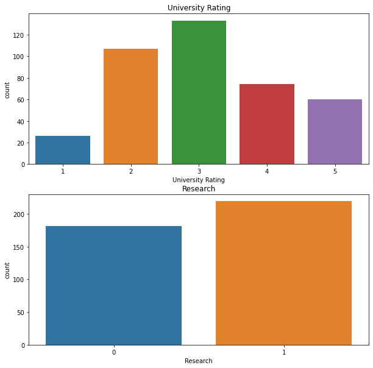

```python
# Visualizing discrete numerical data
l = len(discrete_num_cols)
fig, ax = plt.subplots(l,1,figsize=(10,10))
for i, col in enumerate(discrete_num_cols,0):
    sns.countplot(df[col], ax=ax[i]).set(title=col)
```

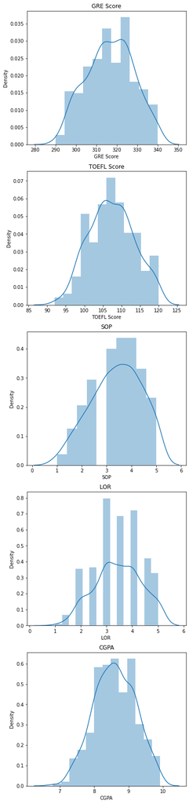

```python
# Visualizing distplot for continuous numerical data
l = len(cont_num_cols)
fig, ax = plt.subplots(l,1,figsize=(6,30))
for i, col in enumerate(cont_num_cols,0):
    sns.distplot(df[col], ax=ax[i]).set(title=col)
```

Inference: Roughly all the continuous features follow normal distribution so, transformation is not needed.

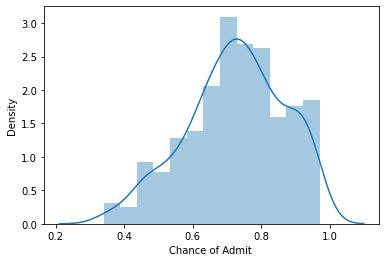

```python
## Seeing distribution of target column
sns.distplot(df['Chance of Admit '])
```

```python
#df['Chance of Admit1 '] = np.exp(df['Chance of Admit '])
```

[figure not shown]

```python
#sns.distplot(df['Chance of Admit1 '])
```

```python
## Dropping original target
#df.drop(columns=['Chance of Admit '], inplace=True)
```

```python
df.columns
```

```
Index(['Serial No.', 'GRE Score', 'TOEFL Score', 'University Rating', 'SOP',
       'LOR ', 'CGPA', 'Research', 'Chance of Admit '],
      dtype='object')
```

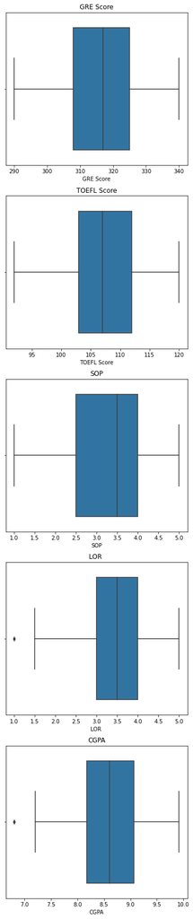

```python
## Seeing outliers in the dataset
l = len(cont_num_cols)
fig, ax = plt.subplots(l,1,figsize=(6,30))
for i, col in enumerate(cont_num_cols,0):
    sns.boxplot(df[col], ax=ax[i]).set(title=col)
```

Inference: As we can see, there are either very less or no outliers in the dataset, so no outlier treatment is required.

```python
df.drop(columns='Serial No.').corr()
```

|  | GRE Score | TOEFL Score | University Rating | SOP | LOR | CGPA | Research | Chance of Admit |
| --- | --- | --- | --- | --- | --- | --- | --- | --- |
| GRE Score | 1.000000 | 0.835977 | 0.668976 | 0.612831 | 0.557555 | 0.833060 | 0.580391 | 0.802610 |
| TOEFL Score | 0.835977 | 1.000000 | 0.695590 | 0.657981 | 0.567721 | 0.828417 | 0.489858 | 0.791594 |
| University Rating | 0.668976 | 0.695590 | 1.000000 | 0.734523 | 0.660123 | 0.746479 | 0.447783 | 0.711250 |
| SOP | 0.612831 | 0.657981 | 0.734523 | 1.000000 | 0.729593 | 0.718144 | 0.444029 | 0.675732 |
| LOR | 0.557555 | 0.567721 | 0.660123 | 0.729593 | 1.000000 | 0.670211 | 0.396859 | 0.669889 |
| CGPA | 0.833060 | 0.828417 | 0.746479 | 0.718144 | 0.670211 | 1.000000 | 0.521654 | 0.873289 |
| Research | 0.580391 | 0.489858 | 0.447783 | 0.444029 | 0.396859 | 0.521654 | 1.000000 | 0.553202 |
| Chance of Admit | 0.802610 | 0.791594 | 0.711250 | 0.675732 | 0.669889 | 0.873289 | 0.553202 | 1.000000 |

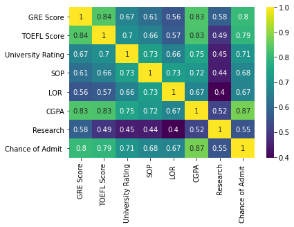

```python
## Examining Correlation between features and target

sns.heatmap(data=df.drop(columns=['Serial No.']).corr(), cmap='viridis', annot=True)
```

Inference: GRE Score, TOEFL Score, CGPA are main contributers to "Chance of Admit"

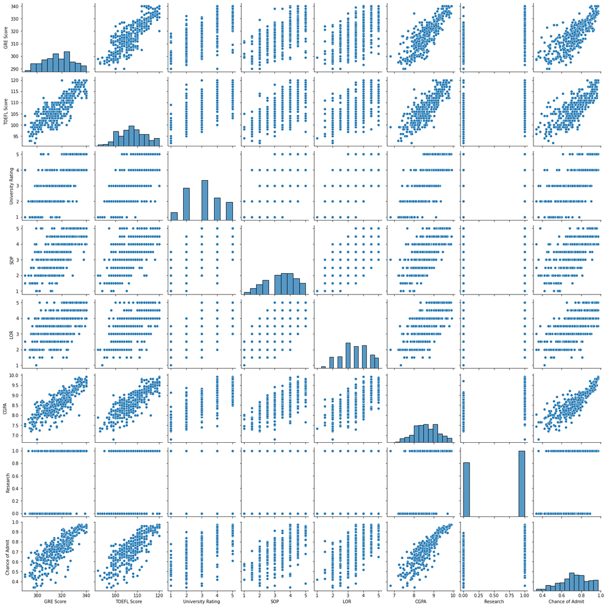

```python
## Let's examine relationships among features and target using pairplot
sns.pairplot(data=df.drop(columns=['Serial No.']))
```

## Splitting data into train and test

```python
### Dividing in features and target
X = df.drop(columns=['Serial No.','Chance of Admit '])
Y = df['Chance of Admit ']
```

```python
### Splitting data into train and test set
X_train, X_test, Y_train, Y_test = train_test_split(X, Y, test_size = 0.30, random_state=42)
```

```python
X_train.shape
```

```
(280, 7)
```

```python
X_test.shape
```

```
(120, 7)
```

```python
X.columns
```

```
Index(['GRE Score', 'TOEFL Score', 'University Rating', 'SOP', 'LOR ', 'CGPA',
       'Research'],
      dtype='object')
```

## Normalizing the input features

```python
mms = MinMaxScaler()
mms.fit(X_train)
```

```
MinMaxScaler()
```

```python
X_train_scaled = mms.transform(X_train)
```

```python
X_test_scaled = mms.transform(X_test)
```

## Model Training & Scoring

```python
rfr = RandomForestRegressor(n_estimators=200,max_depth=3)
rfr.fit(X_train_scaled, Y_train)
train_preds = rfr.predict(X_train_scaled)
test_preds = rfr.predict(X_test_scaled)
```

```python
print('RMSE for training: ', np.sqrt(mean_squared_error(Y_train, train_preds)))
print('RMSE for scoring: ', np.sqrt(mean_squared_error(Y_test, test_preds)))
```

```
RMSE for training:  0.059500285421639494
RMSE for scoring:  0.07140292921280177
```

```python
rfr.score(X_train_scaled, Y_train)
```

```
0.8146920909987203
```

```python
rfr.score(X_test_scaled, Y_test)
```

```
0.7760256324699422
```

Inference: We should thrive for a better testing accuracy

#### On default SVR

```python
svr = SVR()
svr.fit(X_train_scaled, Y_train)
train_preds = svr.predict(X_train_scaled)
test_preds = svr.predict(X_test_scaled)
```

```python
print('RMSE for training: ', np.sqrt(mean_squared_error(Y_train, train_preds)))
print('RMSE for scoring: ', np.sqrt(mean_squared_error(Y_test, test_preds)))
```

```
RMSE for training:  0.06896016381535877
RMSE for scoring:  0.07663165135050622
```

```python
svr.score(X_train_scaled, Y_train)
```

```
0.7510842217795014
```

```python
svr.score(X_test_scaled, Y_test)
```

```
0.7420220243260334
```

Inference: Model seems to be ok, but has less accuracy.

#### On default Linear Regression

```python
lr = LinearRegression()
lr.fit(X_train_scaled, Y_train)
train_preds = lr.predict(X_train_scaled)
test_preds = lr.predict(X_test_scaled)
```

```python
print('RMSE for training: ', np.sqrt(mean_squared_error(Y_train, train_preds)))
print('RMSE for scoring: ', np.sqrt(mean_squared_error(Y_test, test_preds)))
```

```
RMSE for training:  0.06150717710648238
RMSE for scoring:  0.06821159612911354
```

```python
lr.score(X_train_scaled, Y_train)
```

```
0.8019807331500791
```

```python
lr.score(X_test_scaled, Y_test)
```

```
0.7955991554684619
```

Interence: This model looks ok.

#### Ridge Regression

```python
ridge = Ridge(alpha=0.1)
ridge.fit(X_train_scaled, Y_train)
train_preds = ridge.predict(X_train_scaled)
test_preds = ridge.predict(X_test_scaled)
```

```python
print('RMSE for training: ', np.sqrt(mean_squared_error(Y_train, train_preds)))
print('RMSE for scoring: ', np.sqrt(mean_squared_error(Y_test, test_preds)))
```

```
RMSE for training:  0.061520121192889694
RMSE for scoring:  0.06824116334269222
```

```python
ridge.score(X_train_scaled, Y_train)
```

```
0.8018973787082269
```

```python
ridge.score(X_test_scaled, Y_test)
```

```
0.7954219165941357
```

## Feature Importance

```python
X.columns
```

```
Index(['GRE Score', 'TOEFL Score', 'University Rating', 'SOP', 'LOR ', 'CGPA',
       'Research'],
      dtype='object')
```

```python
data_imp = pd.DataFrame({'feature': X.columns, 'importance':lr.coef_}).sort_values(by='importance', ascending=False)
```

```python
data_imp
```

|  | feature | importance |
| --- | --- | --- |
| 5 | CGPA | 0.367593 |
| 0 | GRE Score | 0.091991 |
| 1 | TOEFL Score | 0.088780 |
| 4 | LOR | 0.054778 |
| 2 | University Rating | 0.019465 |
| 6 | Research | 0.018439 |
| 3 | SOP | 0.003979 |

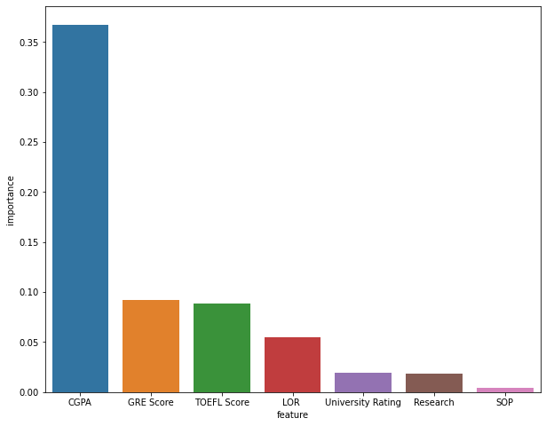

```python
plt.figure(figsize=(10,8))
sns.barplot(x=data_imp['feature'], y = data_imp['importance'])
```

```python
data_imp[data_imp['feature'] == 'GRE Score']
```

|  | feature | importance |
| --- | --- | --- |
| 0 | GRE Score | 0.091991 |

```python
validation_data_features = X_test[20:]
validation_data_targets = Y_test[20:]
```

```python
valid_preds = lr.predict(mms.transform(validation_data_features)) #our best model turned out to be linear regression
```

```python
np.sqrt(mean_squared_error(validation_data_targets, valid_preds))
```

```
0.05952309799260396
```

Inference: RMSE for last 100 rows of validation data